# MT5021 — Övningsprojekt A8 – Tillförsel av kväve till Östersjön

# 1 Sammanfattning

# 2 Inledning

Målet är att modellera och jämföra hur DIN (dissolved inorganic nitrogen) i tillrinnande vattendrag påverkas av avrinningsområdets storlek, befolkning, markanvändning, djurhållning, avrinning samt reningsanslutning, och att bedöma om sambanden skiljer mellan Sverige och övriga länder. Vi utvärderar modeller både för inferens och prediktion (LOOCV).

# 3 Data

**Källa och struktur.** Datasetet `baltic_DIN.csv` består av avrinningsområden med variabler $x_1,\dots,x_{20}$ och respons $y$ (DIN, kg). Vi omvandlar areor från ha till km², bildar loggar och andelar enligt uppgift. Datakontroller (andelar, täthet, arealsummor) utföll väl utan avvikelser av praktisk betydelse.

**Länder och antal.** Datasetet omfattar 7 länder och ett “MISSING” kategori:

```
## [1] "ESTONIA (4), FINLAND (33), LATVIA (5), LITHUANIA (1), MISSING (22), POLAND (2), RUSSIA (2), SWEDEN (36)"
```

Vi ser att Litaun har en observation och Polen och Ryssland har endast 2.

**Variabler (urval).**

| Variabel | Typ | Beskrivning |
| --- | --- | --- |
| $y$ | numerisk | DIN (kg) |
| $x1$ | numerisk | Avrinningsområde (ha $\rightarrow$ km²) |
| $x2$ | numerisk | Befolkning |
| $x3,x4$ | numerisk | Andel stad/land (%) |
| $x5$ | numerisk | Befolkningstäthet (inv/km²) |
| $x6$–$x15$ | numerisk | Markanvändningsareor (ha $\rightarrow$ km²) |
| $x16$ | numerisk | Avrinning (mm/år) |
| $x17,x18$ | numerisk | Svin/Nöt (antal) |
| $x19$ | numerisk | Anslutning reningsverk (%) |
| $x20$ | char | Land |

Vi omvandlade $x20$ till faktor för att utföra R funktioner.

## Data & Förberedelser

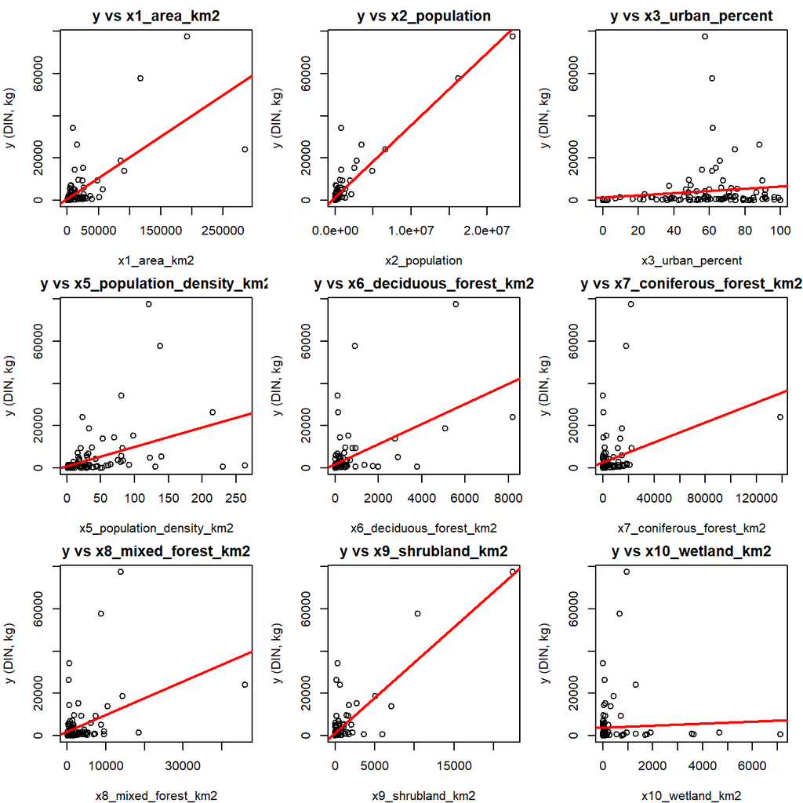

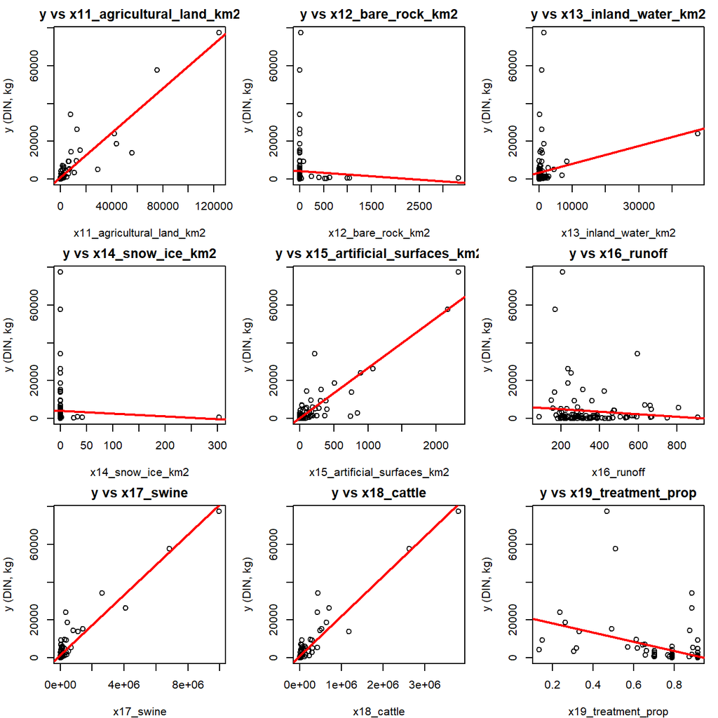

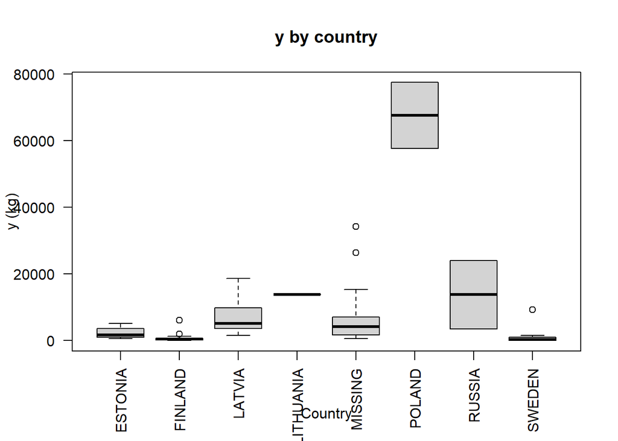

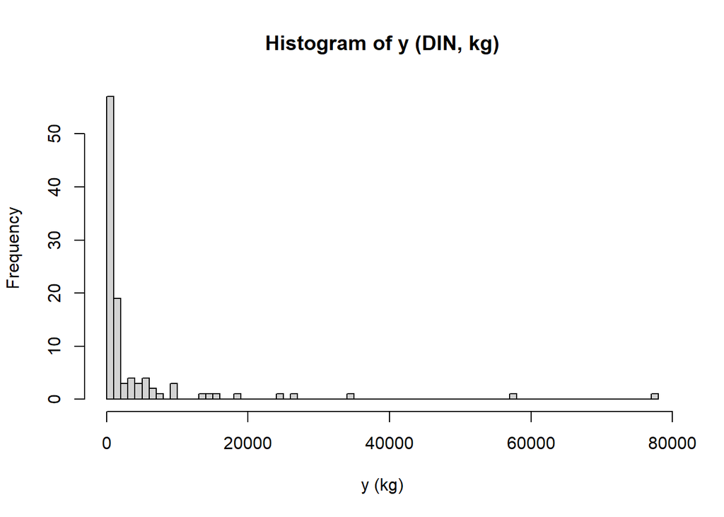

#### Tolkning av scatterplot

Spridningsdiagrammen ($y$ mot $x_1$–$x_{19}$) visar tydligt positiva samband för $x_1$ (area), $x_2$ (befolkning), $x_{11}$ (jordbruksmark), $x_{15}$ (artificiella ytor), $x_{17}$ (svin) och $x_{18}$ (nöt); $x_9$ (buskmark) ser också positiv ut men effekten drivs av några få extrema värden, och $x_{13}$ (inlandsvatten) är svagt–måttligt positiv. Sambanden är svaga eller oklara för $x_3$ (urban andel), $x_5$ (täthet), skogstyperna $x_6$–$x_8$ samt $x_{10}$ (våtmark). Negativ lutning ses för $x_{12}$ (häll/berg), $x_{14}$ (snö/is) och $x_{19}$ (reningsanslutning), medan $x_{16}$ (avrinning) ligger nära noll eller svagt negativ i råa data. Variationen i $y$ ökar med nivån och flera paneler påverkas av några mycket stora vattendrag (heteroskedasticitet och outliers). Boxplottar av $y$ per land visar Polen högst, Ryssland och Lettland mellanhöga samt Sverige och Finland generellt låga nivåer, med stor inomlandsvariation och sned fördelning. Histogrammet visar att $y$ är kraftigt högerskev med några extrema toppar, vilket motiverar en $\log$-transform av $y$; dessutom ligger många punkter långt till vänster i plottarna, vilket ytterligare talar för $\log$-transform för att få en mer symmetrisk fördelning.

# 4 Statistisk modellering

$x_3 + x_4 = 100$ (perfekt kollinearitet), $x_5$ är härledd ur $x_2$ och $x_1$, och summan av markandelsvariablerna $x_6$–$x_{15}$ är $x_1$, vilket ger nära perfekt kollinearitet. Därför behöver vi utesluta minst en variabel (t.ex. $x_{12}$) och vi exkluderar $x_4$, $x_5$ och $x_{12}$ när vi skapar linjära modeller. Vi börjar med att transformera responssvariabeln $y$ samt $x_1$, $x_2$, $x_{17}$ och $x_{18}$. För variablerna $x_6$–$x_{15}$ använder vi proportionerna per observation, det vill säga värdet delat med $x_1$. Efter detta tog vi fram nya spridningsdiagram, histogram och boxplottar för att kontrollera effekterna.

## 4.1 Grundläggande grafer

Vi ser positiva samband för area, befolkning, jordbruk, artificiella ytor, svin och nöt, och ett negativt samband för reningsanslutning. $y$ är högerskev, därför använder vi en log-transform.

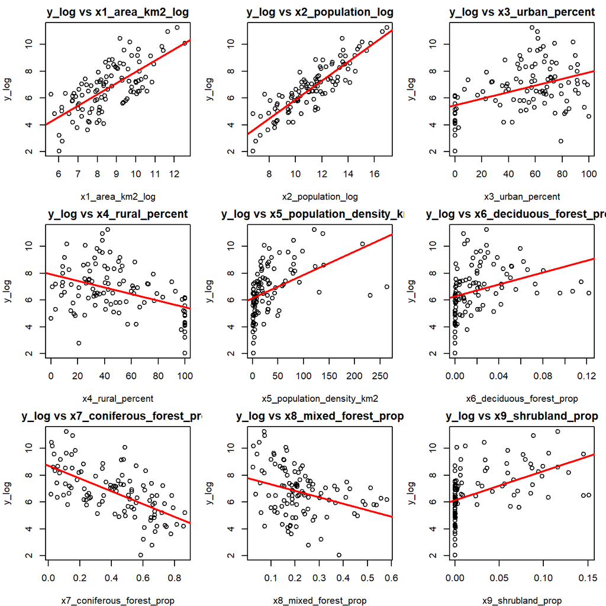

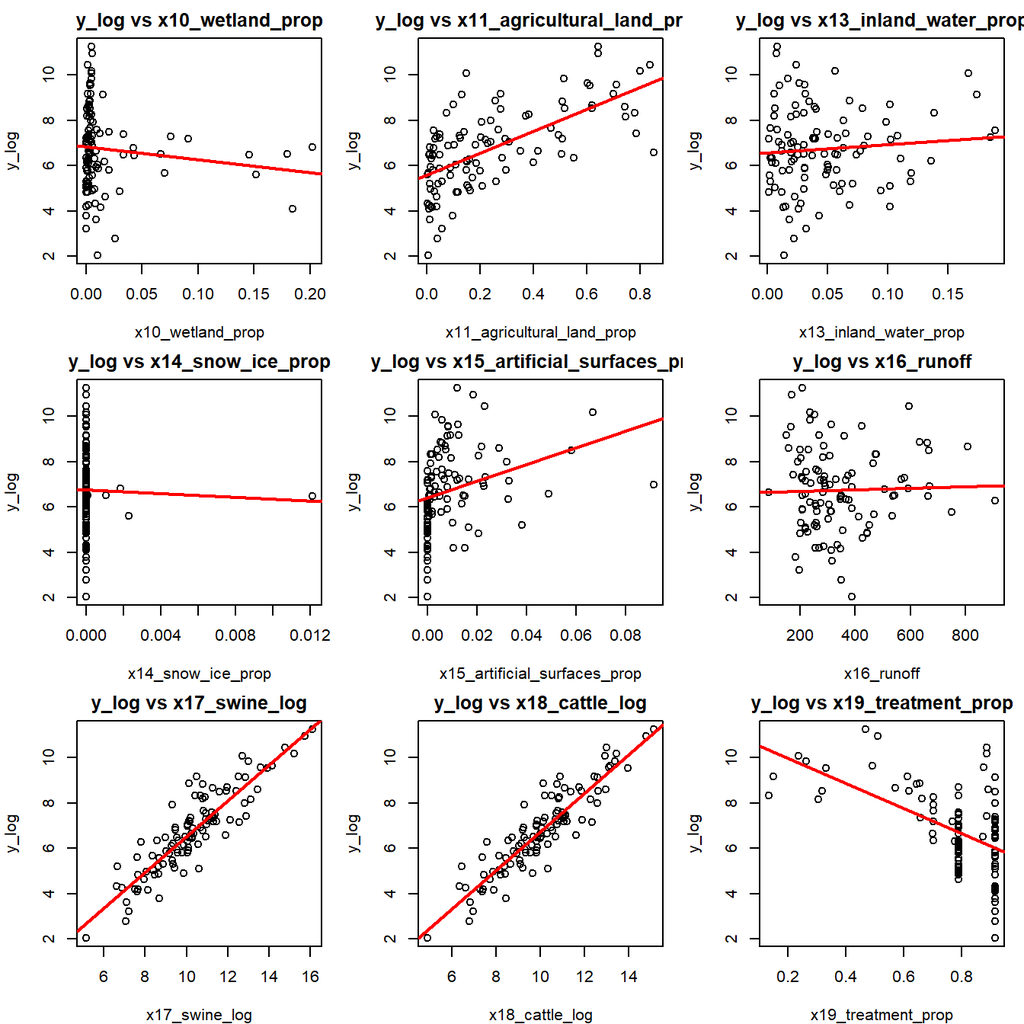

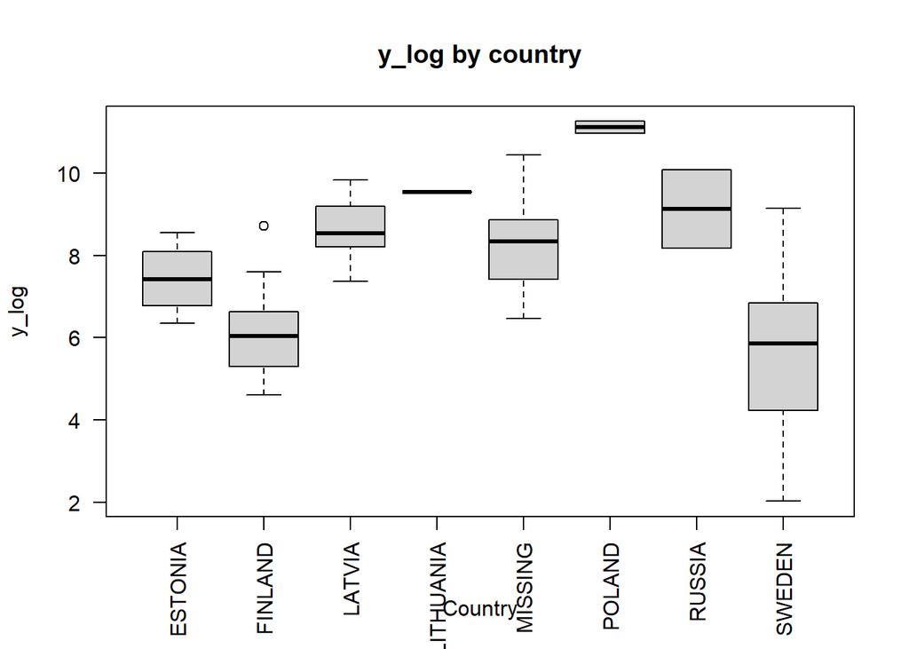

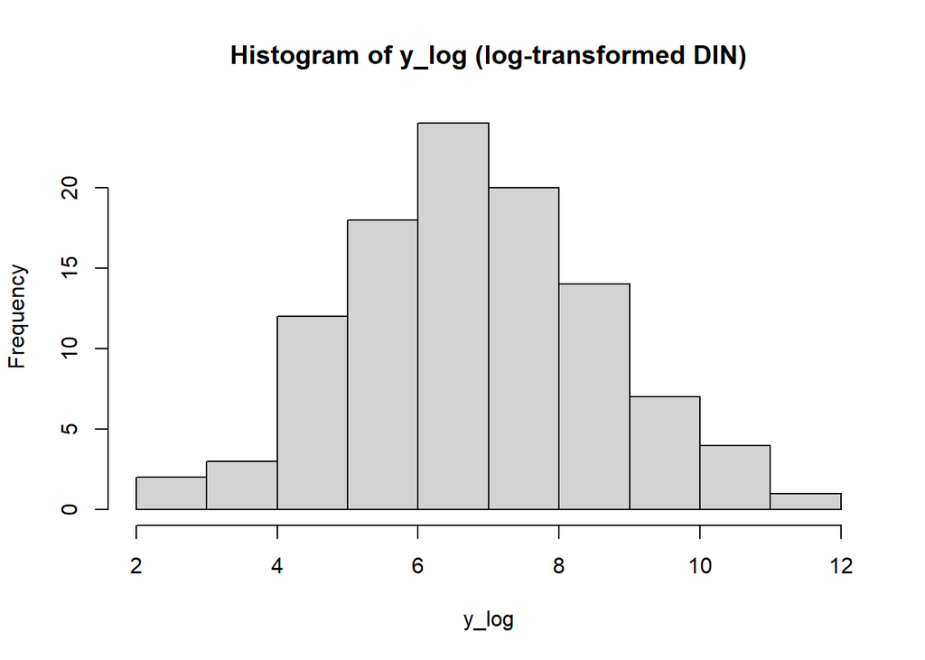

Med $y_{\log}$ som respons ser vi starka positiva samband för x1_area_km2_log, x2_population_log, x5_population_density_km2, x11_agricultural_land_prop, x15_artificial_surfaces_prop, x17_swine_log och x18_cattle_log; även x9_shrubland_prop är positiv men delvis driven av några få stora fall. Sambanden är måttligt till svagt positiva för x3_urban_percent, x6_deciduous_forest_prop och x13_inland_water_prop. Negativa samband ses för x4_rural_percent (spegel av x3), x7_coniferous_forest_prop, x8_mixed_forest_prop och x19_treatment_percent. Nära platta eller svagt negativa samband gäller för x10_wetland_prop, x14_snow_ice_prop samt x16_runoff, som ligger ungefär kring noll. Många av plotten ny visar tydliga linjära samband.

Boxplottar av den loggade responsen visar tydliga länderskillnader: POLAND har högst nivåer och liten spridning; RUSSIA och LITHUANIA ligger mycket högt (Litauen har en enstaka hög observation); LATVIA är också högt. ESTONIA och gruppen MISSING ligger mitt emellan, medan FINLAND och särskilt SWEDEN är lägst; Sverige har dessutom störst spridning bland de låga nivåerna.

Log-transformeringen gör därför att data passar bättre för linjär regression.

## 4.2 Samband i hela Östersjöområdet (log-respons)

Vi testade först alla variabler utan transformation (förutom $x_4$, $x_5$ och $x_{12}$). VIF-värdena var mycket höga för många variabler, vilket visar att variablerna är kollineära. Vi körde step-AIC i båda riktningar på denna modell, men VIF-värdena förblev höga.

Därefter valde vi att gå vidare med annat tillvägagångssätt: med log-transformerade responsvariabeln $y$ och några förklaringsvariabler samt använde andelar för delområdena $x_6$–$x_{15}$. Vi testade alla variabler med dessa transformationer (fortfarande med $x_4$, $x_5$ och $x_{12}$ exkluderade). Efter step-AIC i båda riktningar fick vi en reducerad modell med betydligt lägre VIF. Det justerade $R^2$ var $0.9705$ för den icke-transformerade modellen, vilket var högre än för den transformerade modellen som hade $R^2 = 0.9348$.

Dessa Variabler var i vår modell
$$\begin{aligned}
y_{\log} \sim & \text{x1_area_km2_log} + \text{x2_population_log} \\
& + \text{x3_urban_percent} + \text{x6}\ldots\text{x11} \\
& \text{(proportioner, utom x12)} \\
& + \text{x13} + \text{x14} + \text{x15} \\
& + \text{x16_runoff} + \text{x17_swine_log} \\
& + \text{x18_cattle_log} + \text{x19_treatment_percent} \\
& + \text{x20_country}.
\end{aligned}$$
Sedan testade step-aic på modellen och fick vår reducerade förklaringsmodell.

**Stegvis AIC (båda riktningar).**

```
##
## Call:
## lm(formula = y_log ~ x2_population_log + x3_urban_percent + x6_deciduous_forest_prop +
##     x7_coniferous_forest_prop + x9_shrubland_prop + x16_runoff +
##     x17_swine_log + x19_treatment_prop + x20_country, data = df)
##
## Residuals:
##      Min       1Q   Median       3Q      Max
## -1.05222 -0.33054  0.02721  0.29985  0.94501
##
## Coefficients:
##                            Estimate Std. Error t value Pr(>|t|)
## (Intercept)               -1.622774   0.582625  -2.785  0.00653 **
## x2_population_log          0.331411   0.063599   5.211 1.20e-06 ***
## x3_urban_percent          -0.004195   0.002113  -1.985  0.05020 .
## x6_deciduous_forest_prop   3.747991   2.232128   1.679  0.09664 .
## x7_coniferous_forest_prop  0.725966   0.347321   2.090  0.03945 *
## x9_shrubland_prop          3.154264   1.632690   1.932  0.05655 .
## x16_runoff                 0.002809   0.000337   8.337 8.81e-13 ***
## x17_swine_log              0.473932   0.066013   7.179 2.02e-10 ***
## x19_treatment_prop        -1.212398   0.433287  -2.798  0.00630 **
## x20_countryFINLAND        -0.279977   0.279275  -1.003  0.31881
## x20_countryLATVIA          0.115383   0.317659   0.363  0.71729
## x20_countryLITHUANIA      -0.819364   0.546841  -1.498  0.13758
## x20_countryMISSING        -0.292969   0.270194  -1.084  0.28116
## x20_countryPOLAND         -0.557154   0.460560  -1.210  0.22959
## x20_countryRUSSIA         -0.696897   0.441688  -1.578  0.11816
## x20_countrySWEDEN         -0.889581   0.298397  -2.981  0.00370 **
## ---
## Signif. codes:  0 '***' 0.001 '**' 0.01 '*' 0.05 '.' 0.1 ' ' 1
##
## Residual standard error: 0.4605 on 89 degrees of freedom
## Multiple R-squared:  0.9442, Adjusted R-squared:  0.9348
## F-statistic: 100.4 on 15 and 89 DF,  p-value: < 2.2e-16
```

### VIF-kontroll (numeriska prediktorer)

```
##         x2_population_log          x3_urban_percent  x6_deciduous_forest_prop
##                  8.254936                  1.795104                  1.491762
## x7_coniferous_forest_prop         x9_shrubland_prop                x16_runoff
##                  2.810664                  1.856502                  1.180074
##             x17_swine_log        x19_treatment_prop
##                  7.893635                  1.504509
```

### Diagnostik (log- resp. rå-respons)

Vi testade med att ta fram diagnostikplottarna,

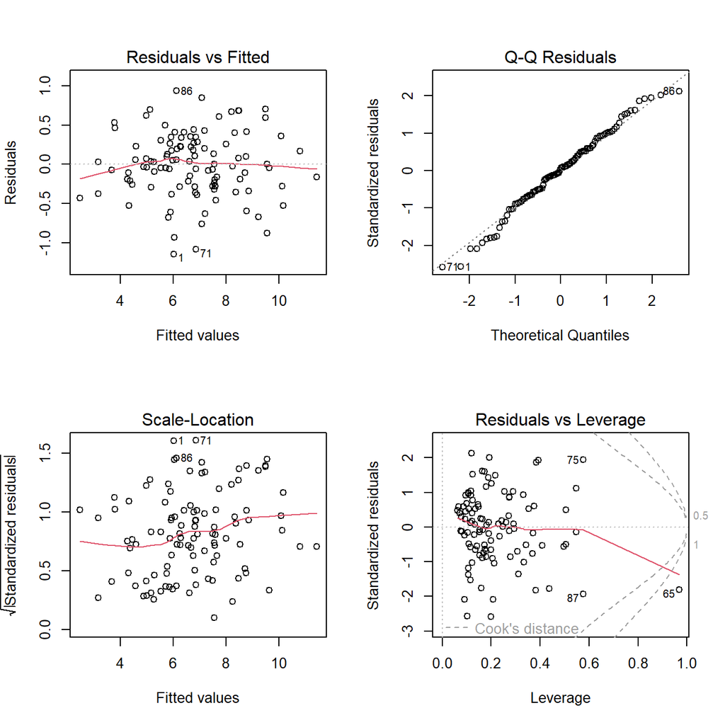

**Stegvis AIC:** Behåller i huvudsak samma kärnsignaler och förenklar modellen: `x2_population_log` **(+),** `x16_runoff` **(+),** `x17_swine_log` **(+),** `x19_treatment_percent` **(–)**. Dessutom svagare markanvändningssamband: `x7_coniferous_forest_prop` **(+),** `x6_deciduous_forest_prop` **(+, gräns),** `x9_shrubland_prop` **(+, gräns),** samt `x3_urban_percent` **(–, gräns)**. **Land:** `SWEDEN` kvarstår **lägre**. Anpassningen är i stort oförändrad (Adj. (R^2 )).

- I hela Östersjöområdet ökar DIN främst med **befolkning**, **avrinning** och **svin**; **hög anslutning till reningsverk minskar** DIN. Skogs-/buskandeler kan bidra svagt positivt. **Sverige har lägre basnivå** än övriga länder givet övriga faktorer.

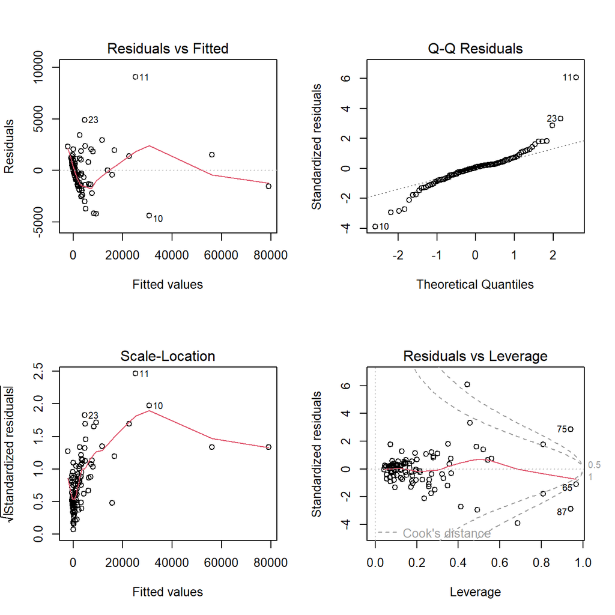

**Diagnostik (rå-respons)**

- **Residuals vs Fitted:** Tydlig kurvatur och kraftig “funnel” → bruten linearitet och stark heteroskedasticitet. Ett par extrema punkter (t.ex. 11, 23, 10) sticker ut.
- **Q–Q:** Klara avvikelser i båda svansar (särskilt övre; 11, 23). Normalantagandet håller dåligt.
- **Scale–Location:** Variansen ökar med anpassat värde → tydlig heteroskedasticitet.
- **Residuals vs Leverage:** Några observationer med mycket hög **leverage** nära/över Cook’s (D) (punkterna längst till höger) → potentiellt starkt inflytande på koefficienterna.

Den linjära modellen på rå skala uppfyller inte antagandena (nonlinearitet, icke-konstant varians, inflytelserika punkter). En log-respons (som i huvudanalysen) är motiverad.

Även om den otransformerade modellen har bättre justerade $R^2$ så kan man inte anta linjära antagande på modellen och använda den. Däremot är den transformerade modellen fyller kraven på linjär regression mycket och är mer relevant.

*Log-modellen uppfyller antagandena bättre än rå-modellen.*

## 4.3 Samma variabler i Sverige som i grannländer?

Vi skapade ett kategorisk variabel “Sweden group” och kategoriserade alla observation om de är Sverige eller inte. Vi skapade ett linjär regression modell på denna alla variabeln och sweden group förutom själva landkategori. Vi körde step-aic på denna variabeln för att få ett mer vald selektion av variabler att köra ett interaktion med. Vi körde anova interaktion test för denna vald del av variabler. Den valda variablerna blev y_log, x1_area_km2_log + x2_population_log + x3_urban_percent + x9_shrubland_prop + x16_runoff + x18_cattle_log + x19_treatment_percent med denna nya variabeln.

**Test av interaktioner och huvudeffekt (Sweden vs Non-Sweden).**

```
## y_log ~ x1_area_km2_log + x2_population_log + x3_urban_percent +
##     x9_shrubland_prop + x16_runoff + x18_cattle_log + x19_treatment_prop
```

|  | Res.Df | RSS | Df | Sum of Sq | F | Pr(>F) |
| --- | --- | --- | --- | --- | --- | --- |
| 1 | 96 | 21.55893 | NA | NA | NA | NA |
| 2 | 89 | 20.15863 | 7 | 1.400305 | 0.8831893 | 0.5231974 |

|  | Res.Df | RSS | Df | Sum of Sq | F | Pr(>F) |
| --- | --- | --- | --- | --- | --- | --- |
| 1 | 97 | 25.15154 | NA | NA | NA | NA |
| 2 | 96 | 21.55893 | 1 | 3.592609 | 15.99757 | 0.0001246828 |

Interaktioner (p = 0,523). Det finns inga bevis för att Sverige reagerar olika på befolkning, avrinning, jordbruk etc. Vi testar också huvudeffekten.

Huvudeffekt (p = 0,0001) Mycket signifikant. Sverige har en annan grundnivå (intercept) för DIN än övriga länder, även efter justering för de 7 variablerna.

RSS-värden:

Utan sweden_group: RSS = 25,15 Med sweden_group: RSS = 21,56 Minskning: 3,59 (14 % mindre oförklarad variation)

Vi kan inte förkasta noll hypotesen att Sverige har samma lutning för variablerna som i granländerna. I andra ord vi kan att Sverige påverkas variabler jämfört med andra länder. Men Sverige har systematiskt lägre DIN-nivåer överlag (annat intercept).

Hypoteserna om Sweden-group och interaktioner bara är giltiga om just den modellen uppfyller LM-antagandena.

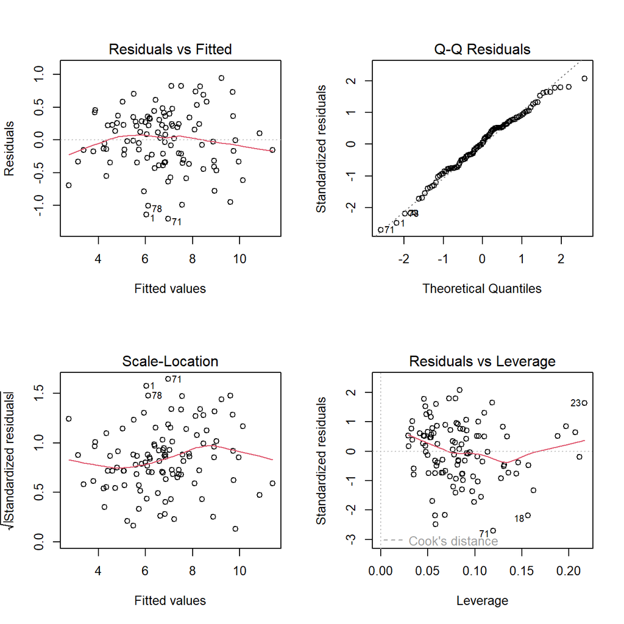

**Diagnostik (vald log-modell)** Residualerna är centrerade kring noll utan tydlig struktur; endast en svag trend anas → linjäritet okej. Q–Q-plotten ligger nära diagonal med små svansavvikelser → normalitetsantagandet rimligt. Scale–Location visar nästan platt loess; något större spridning runt mellannivåer (≈7–8 i fitted) men ingen tydlig funnel → högst mild heteroskedasticitet. Residualer vs leverage: de flesta punkter har låg–måttlig leverage (<≈0.20) och alla ligger inom Cook’s (D<0.5) → inga klart inflytelserika observationer. Modellantagandena är i stort uppfyllda; eventuella små svansar/variansskillnader bedöms inte påverka huvudslutsatserna.

**Full modell med alla prediktorer:**

Vi testade också med anova interaktioner med hela modellen utan att välja med step-aic och fick p = 0,556)

**Inte signifikant.** Samma slutsats som för utvalda variabler: inga bevis för att Sverige reagerar annorlunda på någon av de 16 prediktorerna.

Diagnostikplotterna såg bra ut också på denna fulla modellen.

Vi testade också med den selektion av variablerna från för denna valda förklaringsmodell från 4.2, det visade inte några låg p-värde och kan inte förkasta variabeln.

## 4.4 Prediktion (LOOCV) och Duans smearing

Vi vill nu se om det går att prediktera DIN utifrån förklaringsvariablerna. Här utvärderar vi modellernas **prediktiva precision** med **Leave-One-Out Cross-Validation (LOOCV)**, där vi använder **brute force**: för varje observation $i$ passas modellen om utan $i$, $i$ predikteras på rätt skala, felet sparas, och detta upprepas för alla $n$. För log-responsmodeller **backtransformeras prognoserna med Duan’s smearing**. När man prediktera nya värde med ett modell som man har log-transformerade så finns ett fel med baktransformation, man behöver använda något korrigering i detta Duan’s smearing. Vi måste använda **brute force** istället hat matrisen för log-transformerade modellen eftersom vi behöver beräkna felkorrigering vid varje fall.

Vi jämför tre modellfamiljer och deras stepAIC-varianter: (A) log-respons + log-arealer, (B) log-respons + arealandelar (proportioner), (C) rå respons + råa variabler. **Urvalskriteriet är lägst LOOCV-RMSE på kg-skalan**; justerat $R^2$ rapporteras som komplement. Modellen med lägst LOOCV-RMSE används för slutlig diagnostik och redovisning av prediktioner.

Litauen tas bort i LOOCV eftersom landet har endast en observation, vilket gör att formeln inte kan beräknas när landfaktorn saknas i vissa träningsfolds.

Vi använder Duans smearing för **log-responsmodellerna** (`A`, `B`, `A_step`, `B_mapped`). Mer specifikt backtransformeras varje utelämnad prediktion som:

$$\hat{y} = \exp(\hat{\eta}) \cdot
\underbrace{\mathrm{mean}!\big(\exp(e)\big)}_{\text{smearingfaktor}} -
1,$$

där $\hat{\eta}$ är den predikterade $\log(1+y)$ och $e$ är residualerna från den aktuella träningspassning.

**Tre modellfamiljer.**

| Model | LOOCV_RMSE | Adj_R2 |
| --- | --- | --- |
| LOG-RESP + LOG-AREAS (A) | 3626.017 | 0.9406082 |
| LOG-RESP + PROP-AREAS (B) | 9961.473 | 0.9322361 |
| RAW-RESP + RAW-ALL (C) | 4751.746 | 0.9699852 |

**Tolkning:**

Modell A har lägst LOOCV-RMSE (3626) → bäst prediktion på kg-skalan, med gott justerat $R^2$ ($\approx 0.941$).

Modell C har högre LOOCV-RMSE (4752) men högst justerat $R^2$ ($\approx 0.970$) → passar träningen bäst men predikterar sämre än A.

Modell B är svagast (LOOCV-RMSE 9961; justerat $R^2 \approx 0.932$).

Modell A för bäst här för prediktion.

**LOOCV för step-modeller.**

| Model | LOOCV_RMSE | Adj_R2 |
| --- | --- | --- |
| A_step (LOG-RESP + LOG-AREAS, stepAIC) | 3671.416 | 0.9428590 |
| B_step (LOG-RESP + PROP-AREAS, stepAIC) | 5613.371 | 0.9347983 |
| C_step (RAW-RESP + RAW, stepAIC) | 4653.785 | 0.9704919 |

- **A_step (log $y$, log-areor):** behåller $x2_{\text{pop_log}}(+)$, $x16_{\text{runoff}}(+)$, $x17_{\text{swine_log}}(+)$; mark: $x7(+)$, $x9(+)$, $x11(+)$, $x8(-)$; $x3$ svagt $(-)$. $R^2_{\text{adj}}\approx0.943$, LOOCV RMSE $\approx3671$ (bäst).
- **B_step:** sämst prediktion, LOOCV RMSE $\approx5613$.
- **C_step (rå $y$, råa areor):** många areor $(+)$; $x1(-)$ (”total vs delar”), $x2(-)$ efter kontroll; $x16(+)$, $x17(+)$, $x18(+)$; $x19(-)$. $R^2_{\text{adj}}\approx0.970$, LOOCV RMSE $\approx4654$.

```
##
## Call:
## lm(formula = y_log ~ x2_population_log + x3_urban_percent + x7_coniferous_forest_km2_log +
##     x8_mixed_forest_km2_log + x9_shrubland_km2_log + x11_agricultural_land_km2_log +
##     x16_runoff + x17_swine_log + x18_cattle_log + x19_treatment_prop +
##     x20_country, data = df)
##
## Residuals:
##     Min      1Q  Median      3Q     Max
## -1.0612 -0.2363  0.0180  0.2518  1.1741
##
## Coefficients:
##                                 Estimate Std. Error t value Pr(>|t|)
## (Intercept)                    0.2361757  0.6565208   0.360 0.719915
## x2_population_log              0.3318175  0.0666782   4.976 3.24e-06 ***
## x3_urban_percent              -0.0037869  0.0020355  -1.860 0.066195 .
## x7_coniferous_forest_km2_log   0.1653799  0.0685384   2.413 0.017923 *
## x8_mixed_forest_km2_log       -0.2205546  0.0837394  -2.634 0.009992 **
## x9_shrubland_km2_log           0.0517092  0.0256879   2.013 0.047209 *
## x11_agricultural_land_km2_log  1.0941674  0.3165246   3.457 0.000848 ***
## x16_runoff                     0.0028478  0.0003234   8.806 1.12e-13 ***
## x17_swine_log                  0.5888489  0.2129107   2.766 0.006935 **
## x18_cattle_log                -1.1720642  0.4540882  -2.581 0.011522 *
## x19_treatment_prop             0.9578997  0.6890732   1.390 0.168037
## x20_countryFINLAND             0.5651820  0.3425028   1.650 0.102518
## x20_countryLATVIA              0.3620599  0.3006057   1.204 0.231688
## x20_countryLITHUANIA          -0.1537447  0.5534108  -0.278 0.781815
## x20_countryMISSING             0.0608383  0.2790763   0.218 0.827940
## x20_countryPOLAND              0.0415309  0.4791640   0.087 0.931130
## x20_countryRUSSIA             -0.3458610  0.4374038  -0.791 0.431261
## x20_countrySWEDEN             -0.3455267  0.3179597  -1.087 0.280171
## ---
## Signif. codes:  0 '***' 0.001 '**' 0.01 '*' 0.05 '.' 0.1 ' ' 1
##
## Residual standard error: 0.4311 on 87 degrees of freedom
## Multiple R-squared:  0.9522, Adjusted R-squared:  0.9429
## F-statistic: 101.9 on 17 and 87 DF,  p-value: < 2.2e-16
```